# Uppgift 1 Simulering av normalfordelning

## a) Visualisera fordelningarna i tva histogram. Visualisera fordelningens pdf i samma graf.

Nedan simuleras normalfordelningen med olika antalet dragningar.

```r
x1 <- rnorm(100, mean = 10, sd = 4)
x2 <- rnorm(10000, mean = 10, sd = 4)
```

I figurerna nedan visas resultatet av dragningarna som ett histogram tillsammans med tathetsfunktionen.

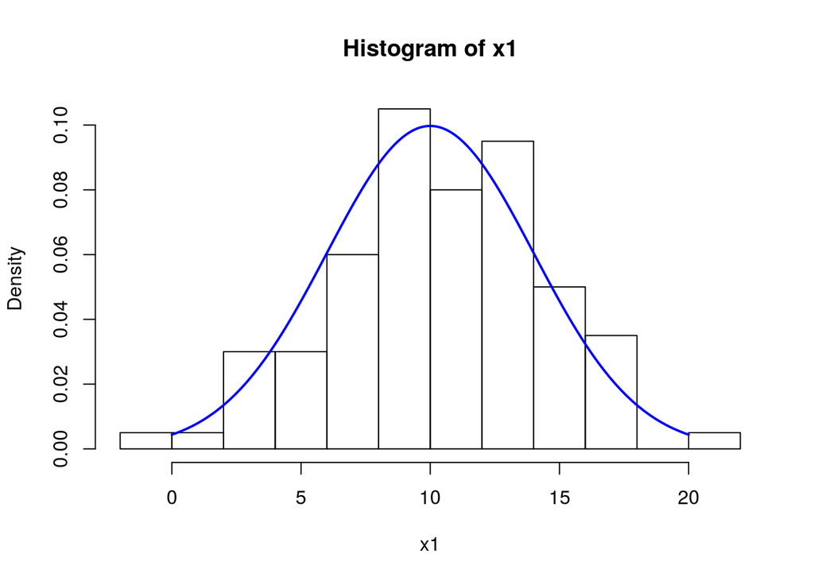

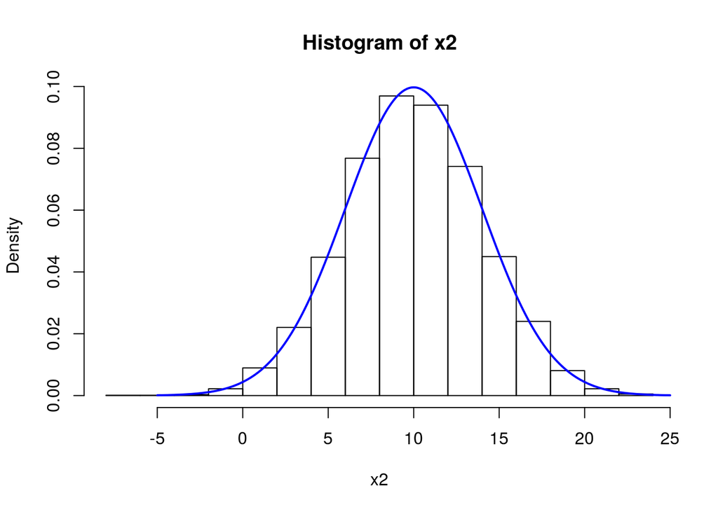

## b) Beskriv skillnaden mellan de olika graferna.

Vi kan tydligare se normalfordelningsformen om vi gor fler dragningar/simuleringar.

## Uppgift 2 Simulera och visualisera andra fordelningar

### a)Simulera och visualisera foljande fordelningar med 10000 dragningar fran varje fordelning samt fordelningens tathetsfunktioner.

```r
x1 <- rbern(10000, 0.2)
x2 <- rbinom(n = 10000, size = 20, prob = 0.1)
x3 <- rbinom(n = 10000, size = 20, prob = 0.5)
x4 <- rgeom(10000, 0.1)
x5 <- rpois(10000, 10)
```

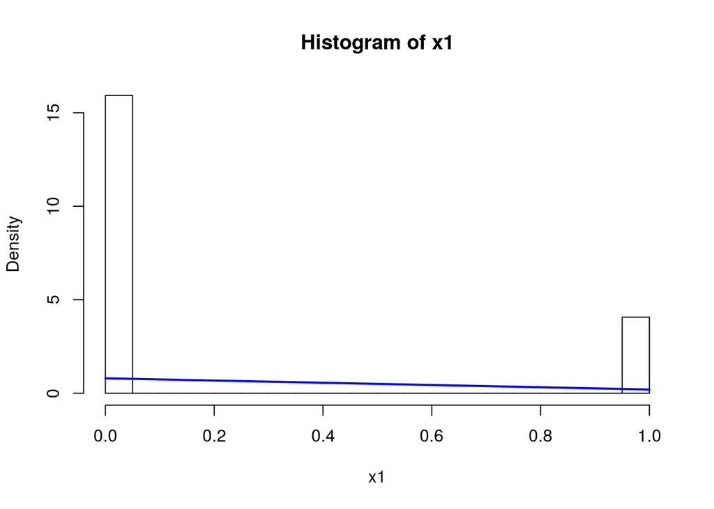

```r
hist(x1, probability = TRUE)
xfit <- seq(0, 1, 1)
yfit <- dbern(xfit, 0.2, log = FALSE)
lines(xfit, yfit, col="blue", lwd=2)
```

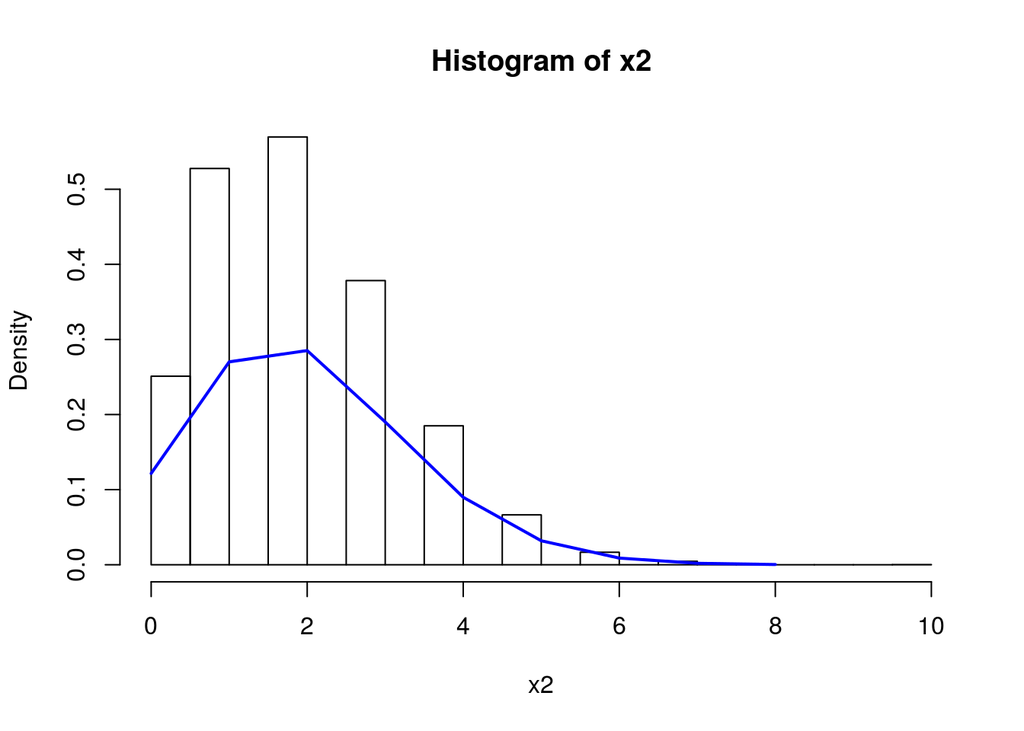

```r
hist(x2, probability = TRUE)
xfit <- seq(0, 8, 1)
yfit <- dbinom(xfit, size = 20, prob = 0.1)
lines(xfit, yfit, col="blue", lwd=2)
```

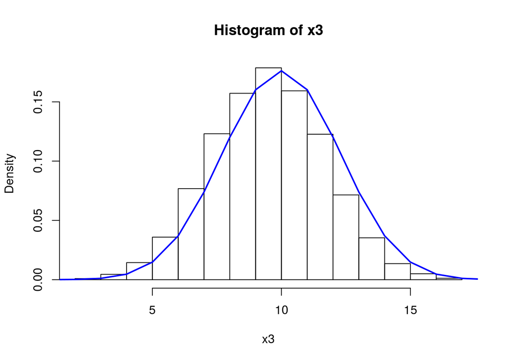

```r
hist(x3, probability = TRUE)
xfit <- seq(0, 20, 1)
yfit <- dbinom(xfit, size = 20, prob = 0.5)
lines(xfit, yfit, col="blue", lwd=2)
```

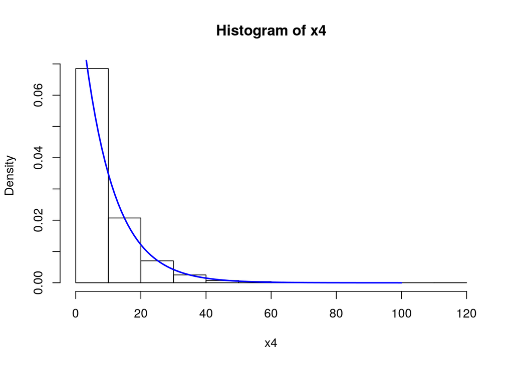

```r
hist(x4, probability = TRUE)
xfit <- seq(0, 100, 1)
yfit <- dgeom(xfit, prob = 0.1)
lines(xfit, yfit, col="blue", lwd=2)
```

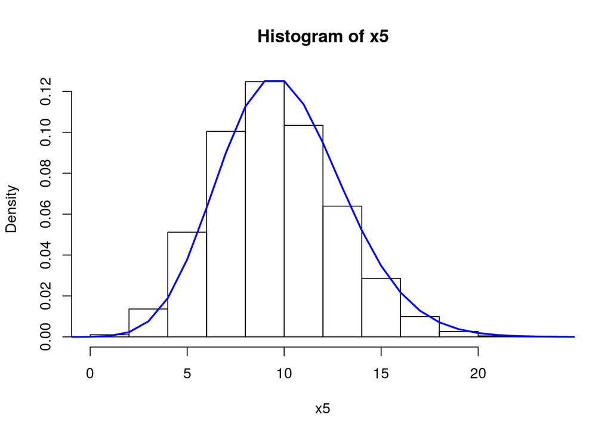

```r
hist(x5, probability = TRUE)
xfit <- seq(-5, 25, 1)
yfit <- dpois(xfit, lambda = 10)
lines(xfit, yfit, col="blue", lwd=2)
```

```r
y1 <- runif(10000, min = 0, max = 1)
y2 <- rexp(10000, rate = 3, beta = 1/3)
y3 <- rgamma(10000, shape=2, rate = 1, scale = 1, alpha = 2, beta = 1)
y4 <- rt(10000, 3)
y5 <- rbeta(10000, 0.1, 0.1, 0)
y6 <- rbeta(10000, 1, 1, 0)
y7 <- rbeta(10000, 10, 5, 0)
```

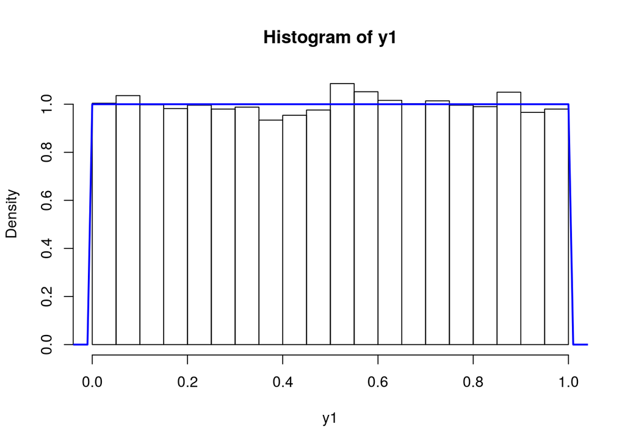

```r
hist(y1, probability = TRUE)
xfit <- seq(-5, 1.1, 0.01)
yfit <- dunif(xfit, min=0, max=1, log=FALSE)
lines(xfit, yfit, col="blue", lwd=2)
```

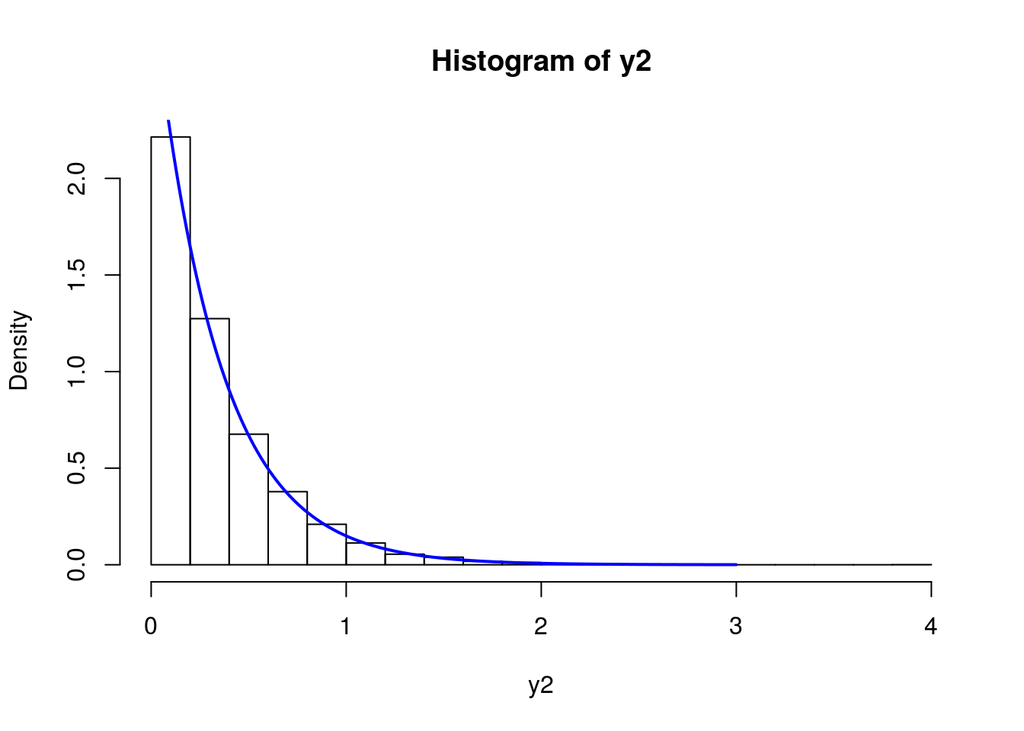

```r
hist(y2, probability = TRUE)
xfit <- seq(0, 3, 0.01)
yfit <- dexp(xfit, rate = 3, beta = 1/3, log = FALSE)
lines(xfit, yfit, col="blue", lwd=2)
```

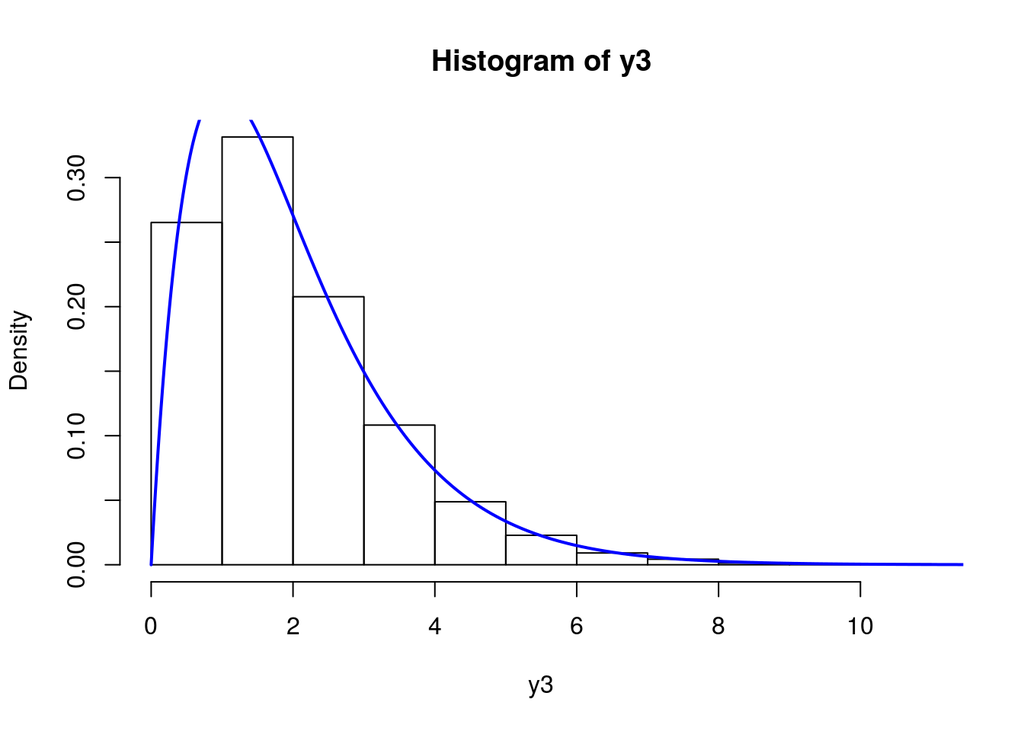

```r
hist(y3, probability = TRUE)
xfit <- seq(0, 12, 0.01)
yfit <- dgamma(xfit, 2, 1, 1, 2, 1, log=FALSE)
lines(xfit, yfit, col="blue", lwd=2)
```

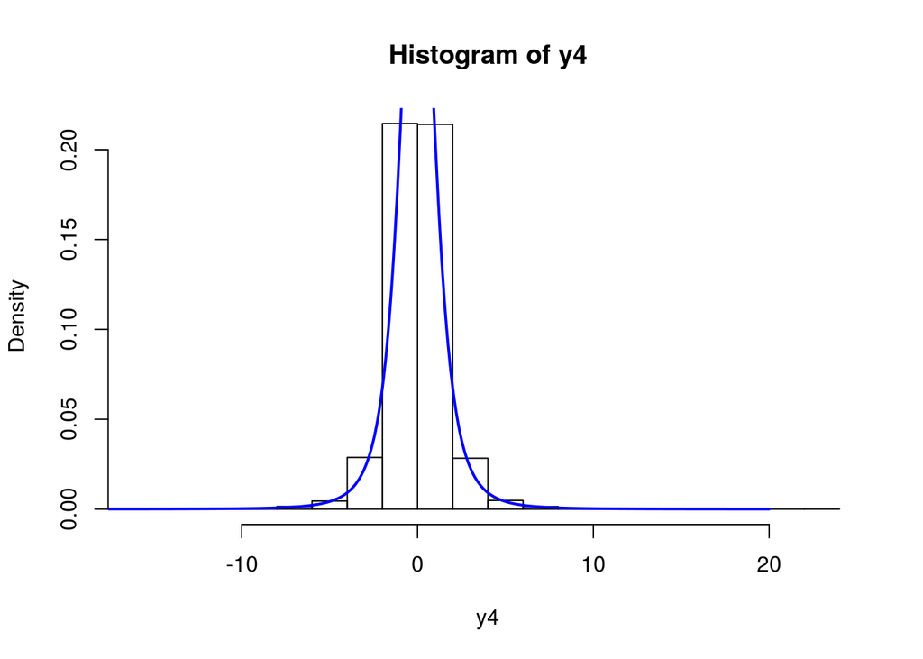

```r
hist(y4, probability = TRUE)
xfit <- seq(-20, 20, 0.01)
yfit <- dt(xfit, 3)
lines(xfit, yfit, col="blue", lwd=2)
```

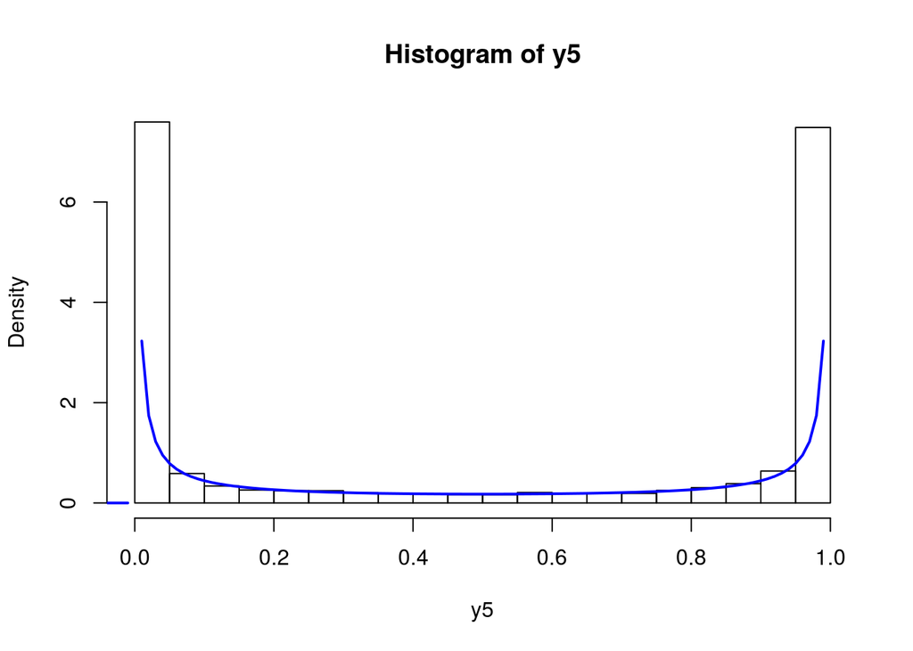

```r
hist(y5, probability = TRUE)
xfit <- seq(-1, 1, 0.01)
yfit <- dbeta(xfit, 0.1, 0.1, 0, log = FALSE)
lines(xfit, yfit, col="blue", lwd=2)
```

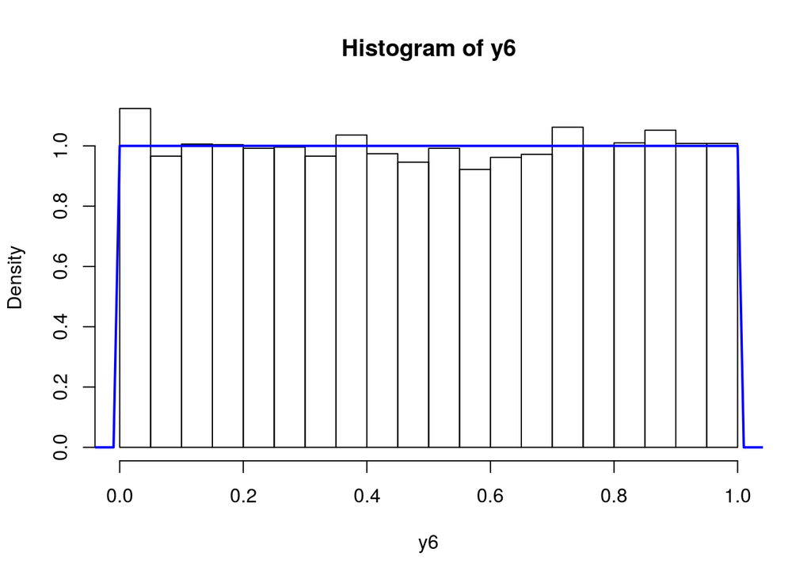

```r
hist(y6, probability = TRUE)
xfit <- seq(-0.1, 1.1, 0.01)
yfit <- dbeta(xfit, 1, 1, 0, log = FALSE)
lines(xfit, yfit, col="blue", lwd=2)
```

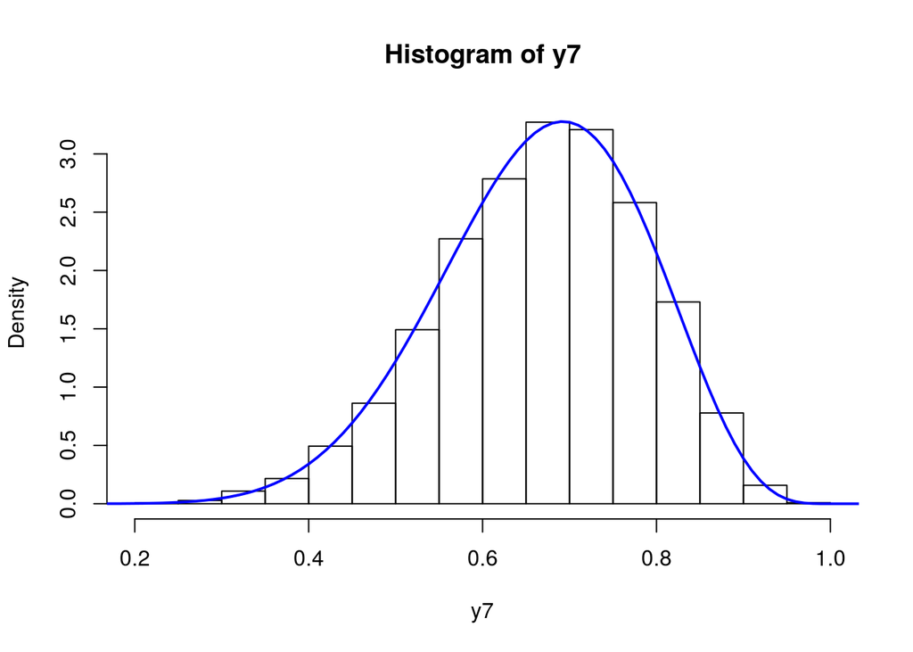

```r
hist(y7, probability = TRUE)
xfit <- seq(-0.1, 1.1, 0.01)
yfit <- dbeta(xfit, 10, 5, 0, log = FALSE)
lines(xfit, yfit, col="blue", lwd=2)
```

## Uppgift 3 Relation mellan fordelningar

### a) Simulera 1000 varden fran respektive fordelning och visualisera fordelningen i ett histogram tillsammans med fordelningens tathetsfunktionen.

```r
x1 <- rbinom(n = 1000, size = 10000, prob = 0.001)
x2 <- rt(1000, 10000)
```

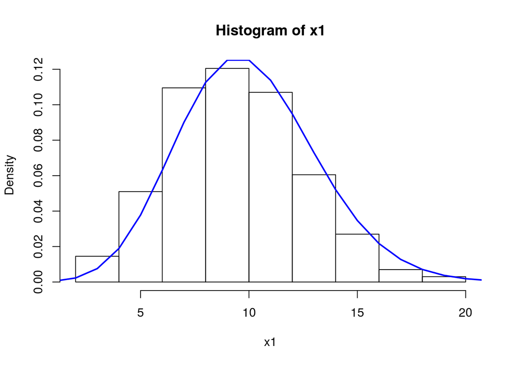

```r
hist(x1, probability = TRUE)
xfit <- seq(0, 25, 1)
yfit <- dbinom(xfit, size = 10000, prob = 0.001)
lines(xfit, yfit, col="blue", lwd=2)
```

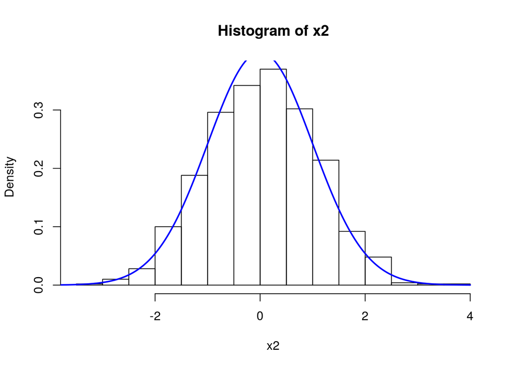

```r
hist(x2, probability = TRUE)
xfit <- seq(-4, 4, 0.01)
yfit <- dt(xfit, 10000)
lines(xfit, yfit, col="blue", lwd=2)
```

### c) Simulera dragningar fran dessa fordelningar och jamfor resultatet med de resultat du fick i a).

```r
x1 <- rnorm(100, mean = 0, sd = 4)
x2 <- rnorm(10000, mean = 0, sd = 4)
```

I figurerna nedan visas resultatet av dragningarna som ett histogram tillsammans med tathetsfunktionen.

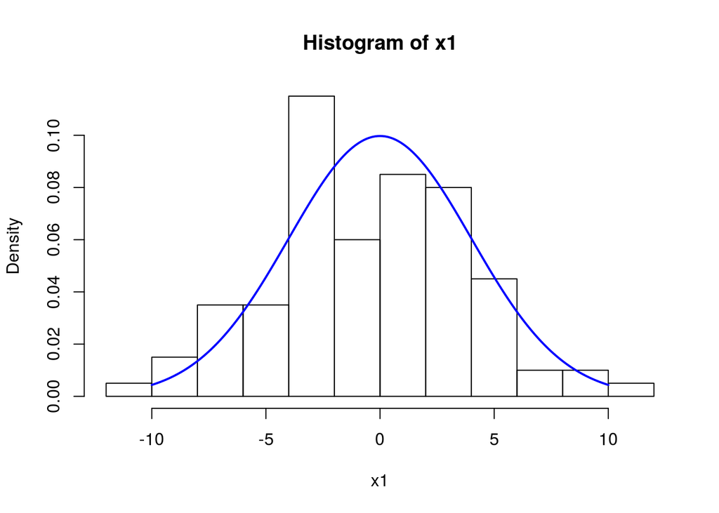

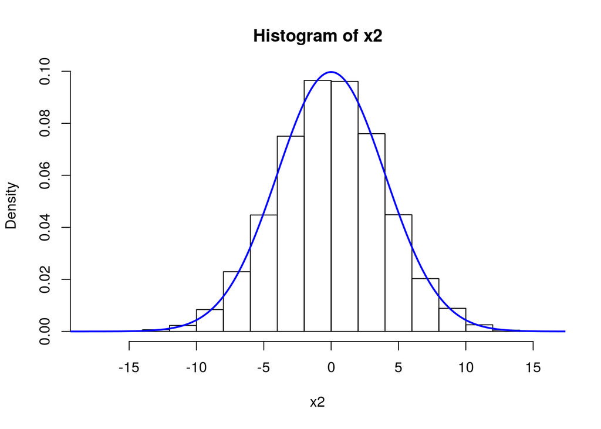

## Uppgift 4 Hiearkiska sannolikhetsfördelningar

### Vi ska nu simulera en blandad sannolikhetsfördelning (mixture distribution). Börja att läsa in data-materialet faithful i R med data(faithful).

### a) Visualisera variabeln waiting i ett histogram.

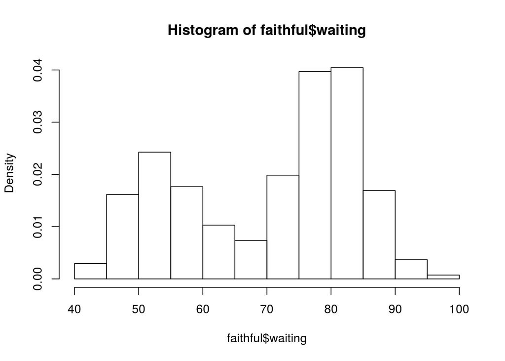

```r
data(faithful)
hist(faithful$waiting, probability = TRUE)
```

### Xi <- Bernoulli(p)

```r
x1 <- rbern(10000, 0.3)
y1 <- numeric(10000)
for(i in 1:10000) {
  y1[i] = x1[i] * rnorm(1, 53, 6) + (1-x1[i]) * rnorm(1, 81,8)
}
```

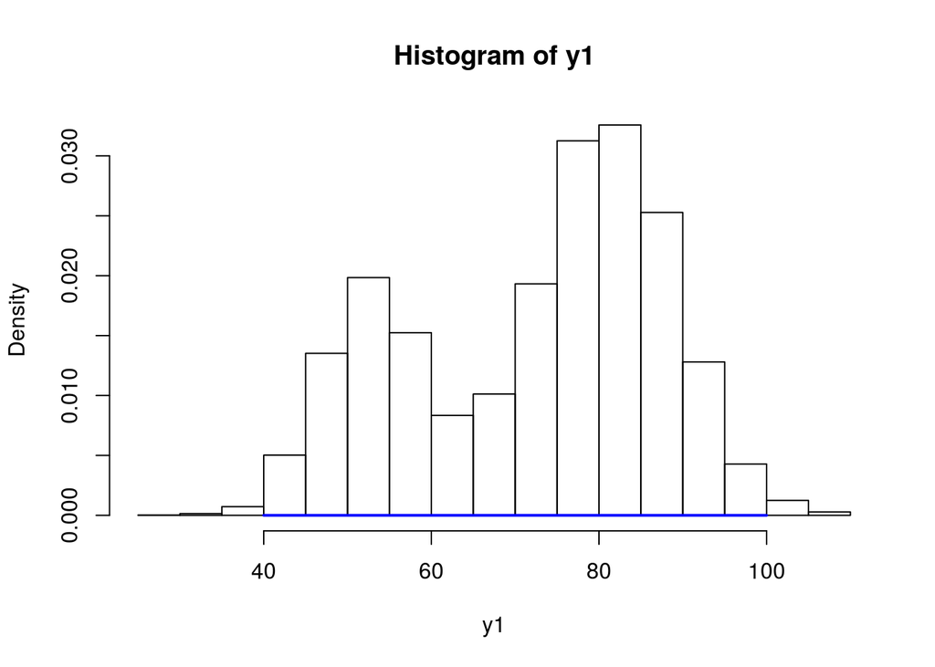

```r
hist(y1, probability = TRUE)
xfit <- seq(40, 100, 1)
yfit <- dbern(xfit, 0.3, log = FALSE)
lines(xfit, yfit, col="blue", lwd=2)
```

## Uppgift 5 Analytisk sannolikhet och approximation med ”Monte Carlo” - metoder

```r
x1 <- rnorm(10000, 0, 1)
y1 <- rbinom(10000, 10, 0.1)
```

### a)

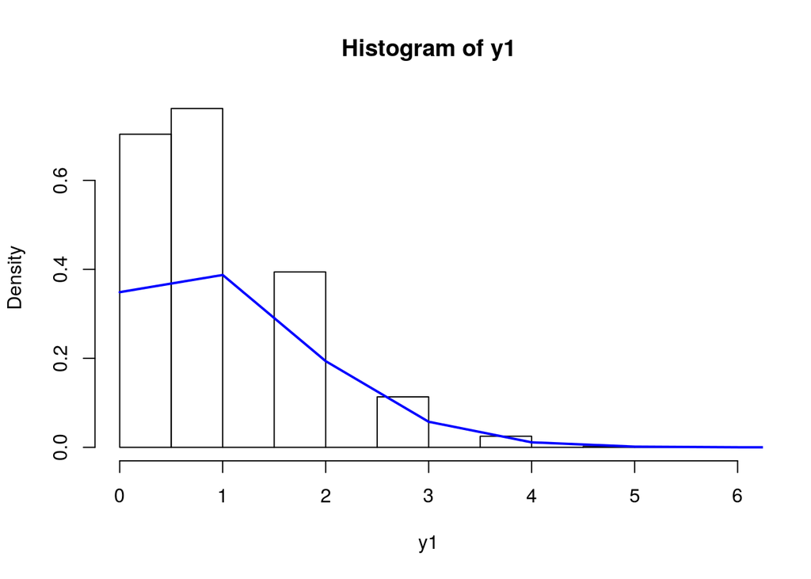

```r
hist(y1, probability = TRUE)
xfit <- seq(0, 10, 1)
yfit <- dbinom(xfit, 10, 0.1)
lines(xfit, yfit, col="blue", lwd=2)
```

### b)

#### 1 P(X < 0)

```r
pnorm(0, mean = 0, sd = 1)
```

```
## [1] 0.5
```

#### 2 P( 1 < X < 1)

```r
pnorm(1, mean = 0, sd = 1) - pnorm(-1, mean = 0, sd = 1)
```

```
## [1] 0.6826895
```

#### 3 P(1.96 < X)

```r
1 - pnorm(1.96, mean = 0, sd = 1)
```

```
## [1] 0.0249979
```

#### 4 P(0 < Y < 10)

```r
pbinom(10, size = 10, prob = 0.1)  - pbinom(0.0, size = 10, prob = 0.1)
```

```
## [1] 0.6513216
```

## FEL

#### 5 P(Y = 0)

```r
pbinom(0.0, size = 10, prob = 0.1)
```

```
## [1] 0.3486784
```

### 6 P (0 <= Y <= 10)

```r
pbinom(10.0, size = 10, prob = 0.1) - pbinom(0.0, size = 10, prob = 0.1)
```

```
## [1] 0.6513216
```

### c)

#### 1 P(X < 0)

```r
x1 <- rnorm(10000, 0, 1)
p = ecdf(x1)
p(0.0)
```

```
## [1] 0.5039
```

#### 2 P( 1 < X < 1)

```r
x2 <- rnorm(10000, 0, 1)
p = ecdf(x2)
p(1.0) - p(-1.0)
```

```
## [1] 0.6903
```

#### 3 P(1.96 < X)

```r
x3 <- rnorm(10000, 0, 1)
p = ecdf(x3)
1 - p(1.96)
```

```
## [1] 0.0255
```

#### 4 P(0 < Y < 10)

```r
y1 <- rbinom(10000, 10, 0.1)
p = ecdf(y1)
p(10.0) - p(0.0)
```

```
## [1] 0.6426
```

## FEL

#### 5 P(Y = 0)

```r
y2 <- rbinom(10000, 10, 0.1)
p = ecdf(y2)
p(0.0)
```

```
## [1] 0.3461
```

### 6 P (0 <= Y <= 10)

```r
y3 <- rbinom(10000, 10, 0.1)
p = ecdf(y3)
p(10.0) - p(0.0)
```

```
## [1] 0.661
```

## Uppgift 6 Beräkna (icke-triviala) sannolikheter

## a)

### Förväntade antalet fel: Gamla systemet

```r
old <- rbinom(10000, size = 337, prob = 0.1)
evold <- mean(old)
print(evold)
```

```
## [1] 33.7585
```

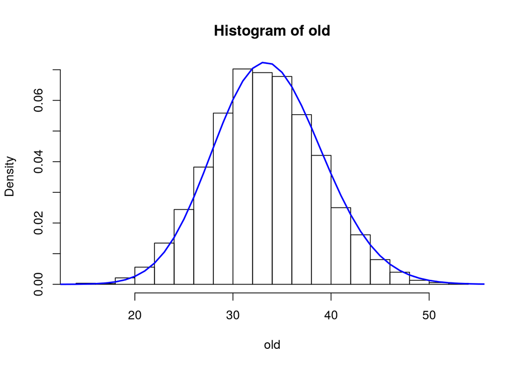

```r
hist(old, probability = TRUE)
xfit <- seq(0, 337, 1)
yfit <- dbinom(xfit, 337, 0.1)
lines(xfit, yfit, col="blue", lwd=2)
```

### Förväntade antalet fel: Nya systemet

```r
newprob <- runif(10000, min = 0.02, max = 0.16)
evnewprob <- mean(newprob)
new <- rbinom(10000, size = 337, prob = evnewprob)
evnew <- mean(new)
print(evnew)
```

```
## [1] 30.1237
```

## P(färre fel i gamla systemet än nya) = intervallet [0.1, 0.16] / intervallet [0.02, 0.16] = 0.06/0.14 = 0.429

## sannolikheten att du kommer få fler än 50 fel i gamla systemet

```r
p <- ecdf(old)
print(1-p(50))
```

```
## [1] 0.0017
```

## sannolikheten att du kommer få fler än 50 fel i nya systemet

```r
p <- ecdf(new)
print(1-p(50))
```

```
## [1] 2e-04
```

### Uppgift 7 Monte Carlo metoder för integrering

## a)

```r
montecarlocalcpi <- function(n) {

x <- runif(n, min = 0.0, max = 1.0)
y <- runif(n, min = 0.0, max = 1.0)

i <- 1
while (i <= length(x)) {
  eq <- (x[i]*x[i]+y[i]*y[i])**(1/2)
  if (eq > 1) {
    x <- x[-i]
    y <- y[-i]
  }
  else {
    i <- i + 1
  }
}

z <- length(x)

plot(x, y)

const <- 4 * z/n

return(const)
}
```

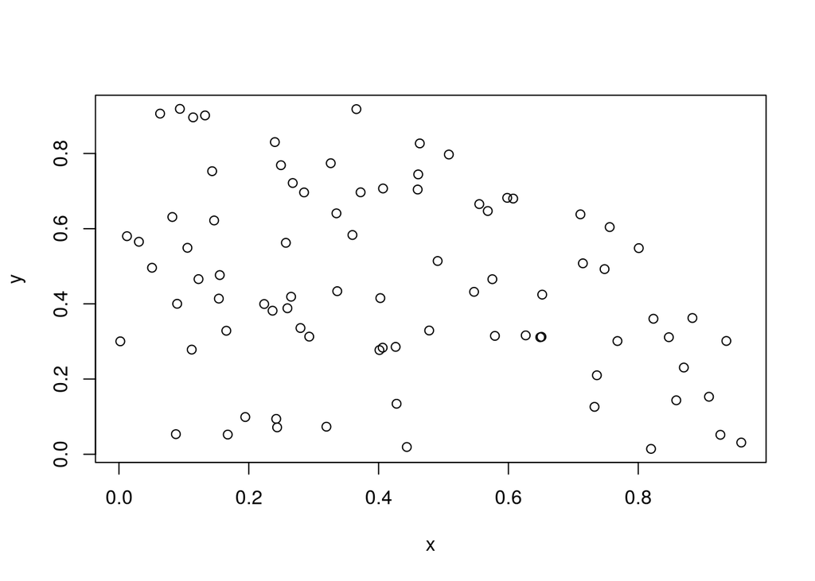

```
## [1] 3.32
```

```r
montecarlocalcpi(100)
```

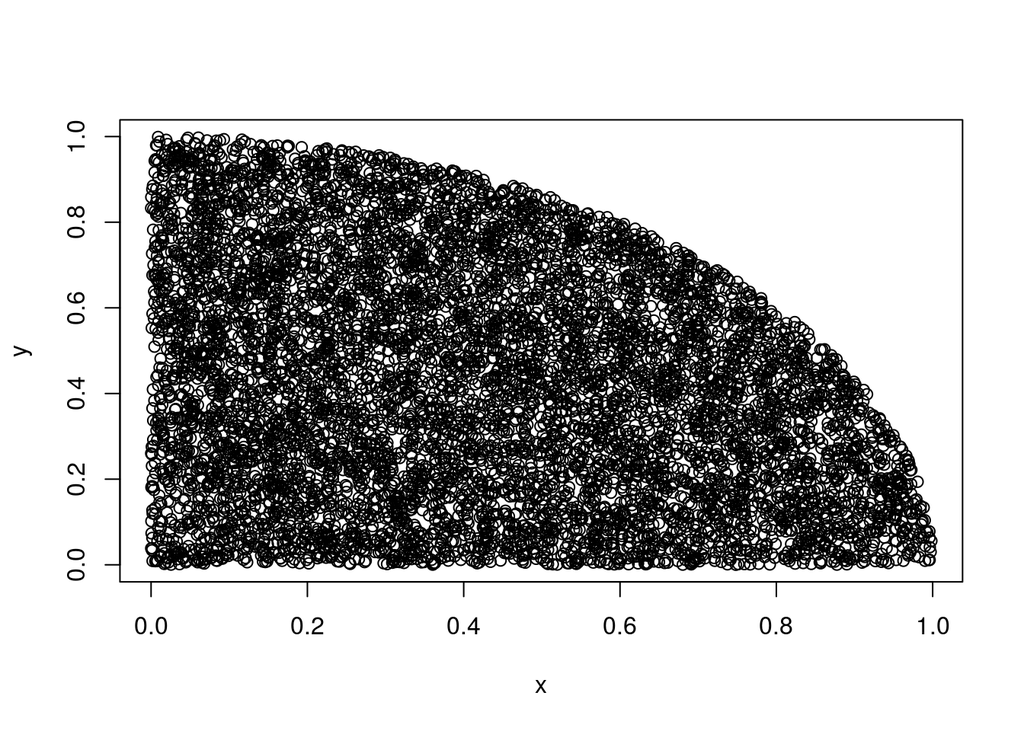

```
## [1] 3.1724
```

```r
montecarlocalcpi(10000)
```

```r
#montecarlocalcpi(100000)
```

```r
#montecarlocalcpi(1000000)
```

### b)

Vi försöker approximera pi, vilket verkar gå ganska väl både sett till talet man får fram samt den grafiska kvartscirkeln.

### c)

Approximationen blir exaktare, men beräkningen tar mycket längre tid.

### d)

```r
x2 <- function(n) {
  return(n*n)
}
integrate(x2, lower = 0, upper = 2)
```

```
## 2.666667 with absolute error < 3e-14
```

### e)

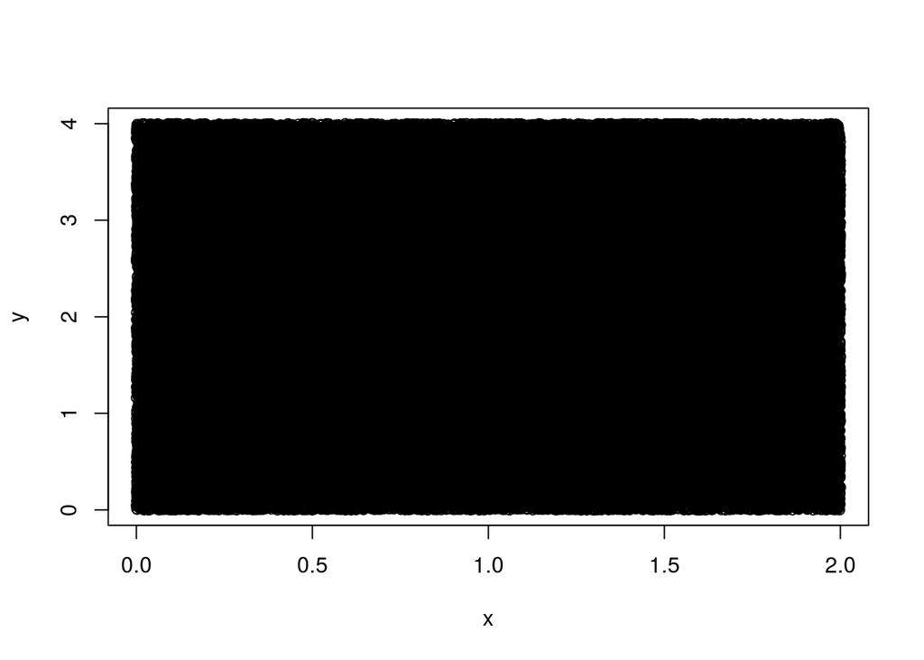

```
## [1] 2.67768
```

```r
montecarlocalc <- function(n) {

x <- runif(n, min = 0.0, max = 2.0)
y <- runif(n, min = 0.0, max = 4.0)

plot(x,y)

return(mean(y < x**2)*8)
}

montecarlocalc(100000)
```

### Uppgift 8 Stora talens lag

```r
binomfunc <- function(n) {
  x <- rbinom(n, size = 10, prob = 0.2)
  return(x)
}

gammafunc <- function(n) {
  y <- rgamma(n, shape = 2, rate = 2)
  return(y)
}
```

### a)

E[X] = size * prob = 10 * 0.2 = 2

### b)

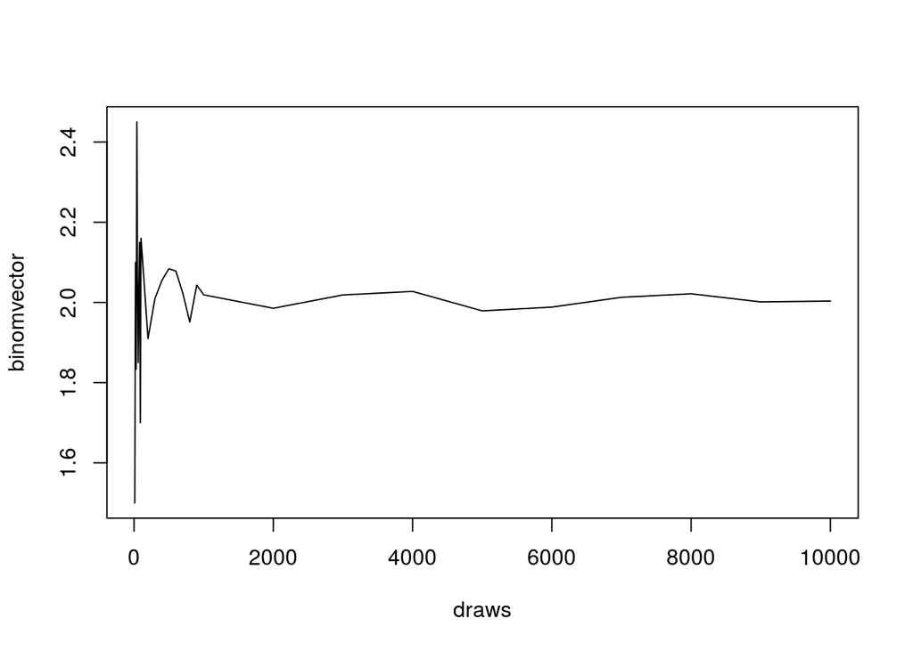

```r
binomvector <- c()
draws <- c()

n <- 0
while (n < 10000) {
  if(n < 100) {
    n <- n + 10
  }
  else if (n < 1000) {
    n <- n + 100
  }
  else if (n < 10000) {
    n <- n + 1000
  }
  x <- mean(binomfunc(n))
  binomvector <- c(binomvector, x)
  draws <- c(draws, n)
}

plot(draws, binomvector, type = "l")
```

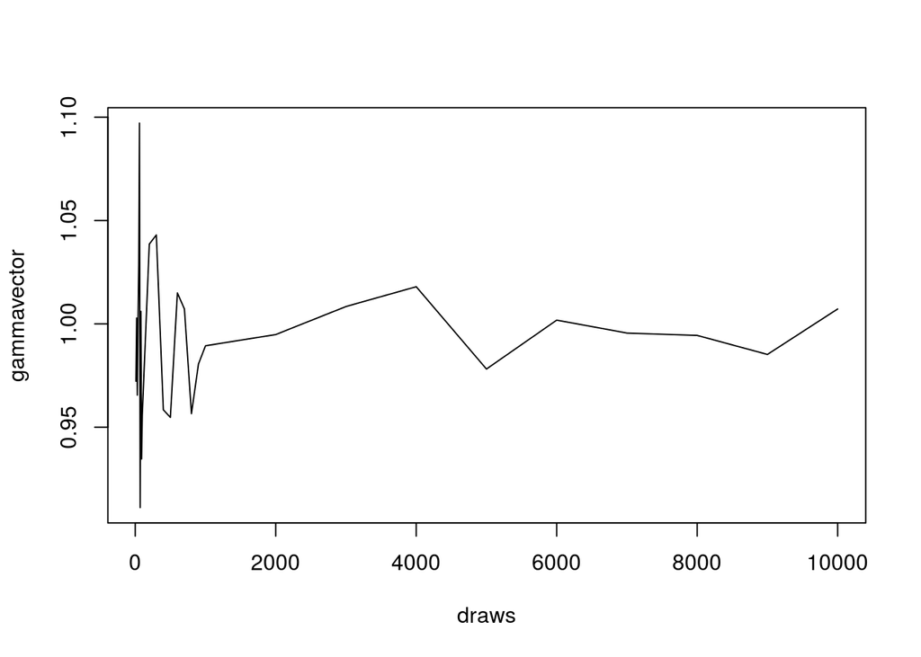

```r
gammavector <- c()
draws <- c()

n <- 0
while (n < 10000) {
  if(n < 100) {
    n <- n + 10
  }
  else if (n < 1000) {
    n <- n + 100
  }
  else if (n < 10000) {
    n <- n + 1000
  }
  x <- mean(gammafunc(n))
  gammavector <- c(gammavector, x)
  draws <- c(draws, n)
}

plot(draws, gammavector, type = "l")
```

### Uppgift 9 Väntevärde och varians

```r
exponentialfunc <- function(n) {
 x <- rexp(n, rate = 10)
 return(x)
}

poissonfunc <- function(n) {
  y <- rpois(n, lambda = 3)
  return(y)
}
```

## a)

E[X] = 1/rate = 1/10 = 0.1

Var[X] = 1/rate² = 1/100 = 0.01

E[Y] = lambda = 3

Var[Y] = lambda = 3

## b)

```r
# Beräknar E(X)
mean(exponentialfunc(10000))
```

```
## [1] 0.09927041
```

```r
# Beräknar Var(X)
var(exponentialfunc(10000))
```

```
## [1] 0.009971177
```

```r
# Beräknar E(Y)
mean(poissonfunc(10000))
```

```
## [1] 2.9908
```

```r
# Beräknar Var(Y)
var(poissonfunc(10000))
```

```
## [1] 3.038925
```

## c)

1. E(3) = 3
2. E(3 * X + 2) = 3 * E(X) + 2 = 3 * 0.1 + 2 = 2.3
3. E(X + Y) = E(X) + E(Y) = 0.1 + 3 = 3.1
4. E(X * Y) = E(X) * E(Y) = 0.1 * 3 = 0.3
5. E(3 * X + 2 * Y - 3) = 3 * E(X) + 2 * E(Y) - 3 = 3 * 0.1 + 2 * 3 - 3 = 3.3
6. Var(2 * X - 5) = 2² * Var(X) = 4 * 0.01 = 0.04
7. Var(X + Y) = Var(X) + Var(Y) = 0.01 + 3 = 3.01

## d)

```r
x <- exponentialfunc(10000)
y <- poissonfunc(10000)

#1
mean(3)
```

```
## [1] 3
```

```r
#2
mean(3*x+2)
```

```
## [1] 2.292886
```

```r
#3
mean(x+y)
```

```
## [1] 3.075729
```

```r
#4
mean(x*y)
```

```
## [1] 0.2931294
```

```r
#5
mean(3*x+2*y-3)
```

```
## [1] 3.249086
```

```r
#6
var(2*x-5)
```

```
## [1] 0.03732443
```

```r
#7
var(x+y)
```

```
## [1] 2.967211
```

### Uppgift 10 Centrala gränsvärdessatsen

```r
poissonfunc <- function(n) {
  x <- rpois(n, lambda = 5)
  return(x)
}

exponentialfunc <- function(n) {
 y <- rexp(n, rate = 1)
 return(y)
}

binomfunc <- function(n) {
  z <- rbinom(n, size = 10, prob = 0.01)
  return(z)
}
```

## a)

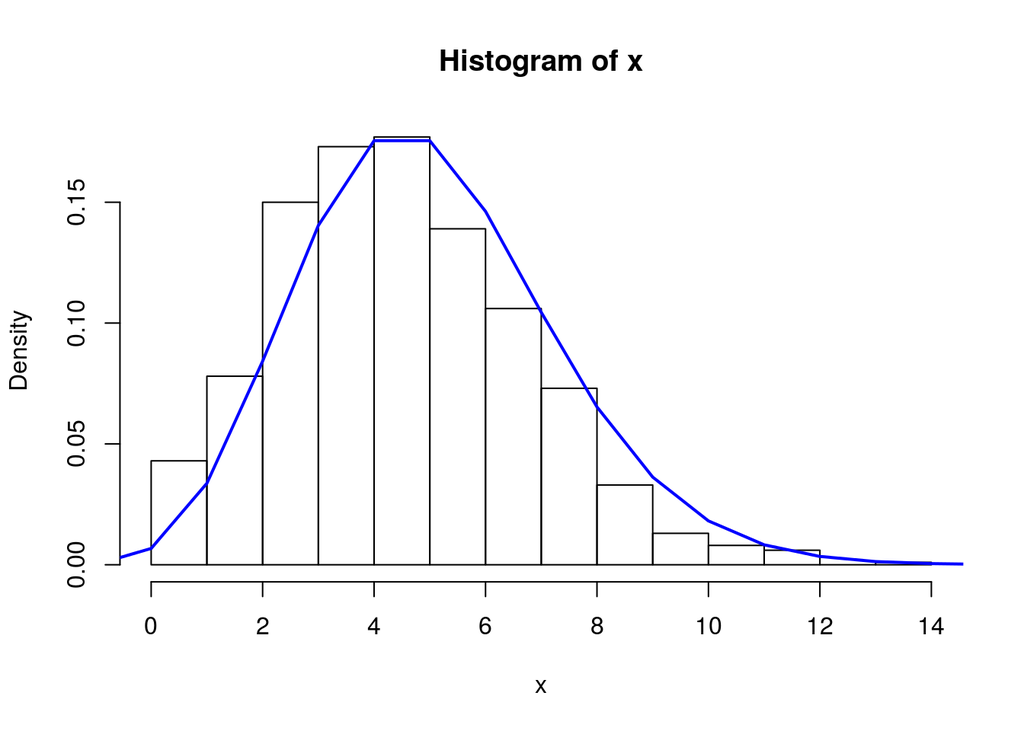

```r
x <- poissonfunc(1000)
hist(x, probability = TRUE)
xfit <- seq(-5, 15, 1)
yfit <- dpois(xfit, lambda = 5)
lines(xfit, yfit, col="blue", lwd=2)
```

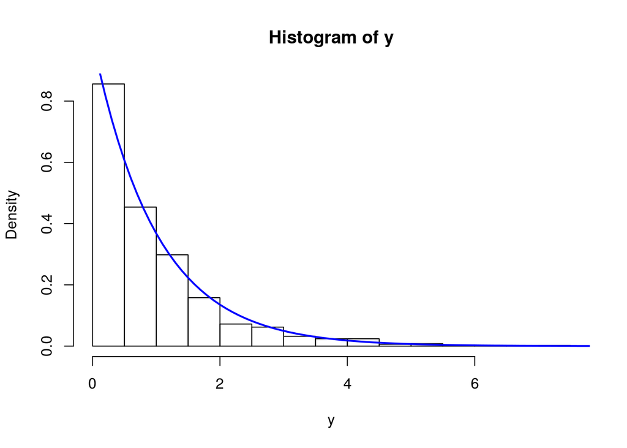

```r
y <- exponentialfunc(1000)
hist(y, probability = TRUE)
xfit <- seq(0, 10, 0.1)
yfit <- dexp(xfit, 1)
lines(xfit, yfit, col="blue", lwd=2)
```

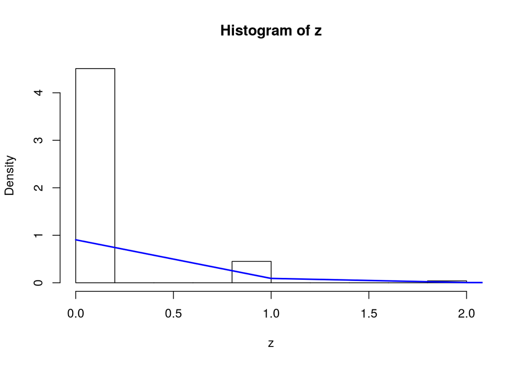

```r
z <- binomfunc(1000)
hist(z, probability = TRUE)
xfit <- seq(0, 3, 1)
yfit <- dbinom(xfit, size = 10, prob = 0.01)
lines(xfit, yfit, col="blue", lwd=2)
```

## b)

```r
poisvector <- c()
expvector <- c()
i = 1
while (i < 1000) {
  poisvector <- c(poisvector, mean(poissonfunc(10)))
  expvector <- c(expvector, mean(exponentialfunc(10)))
  i <- i + 1
}
```

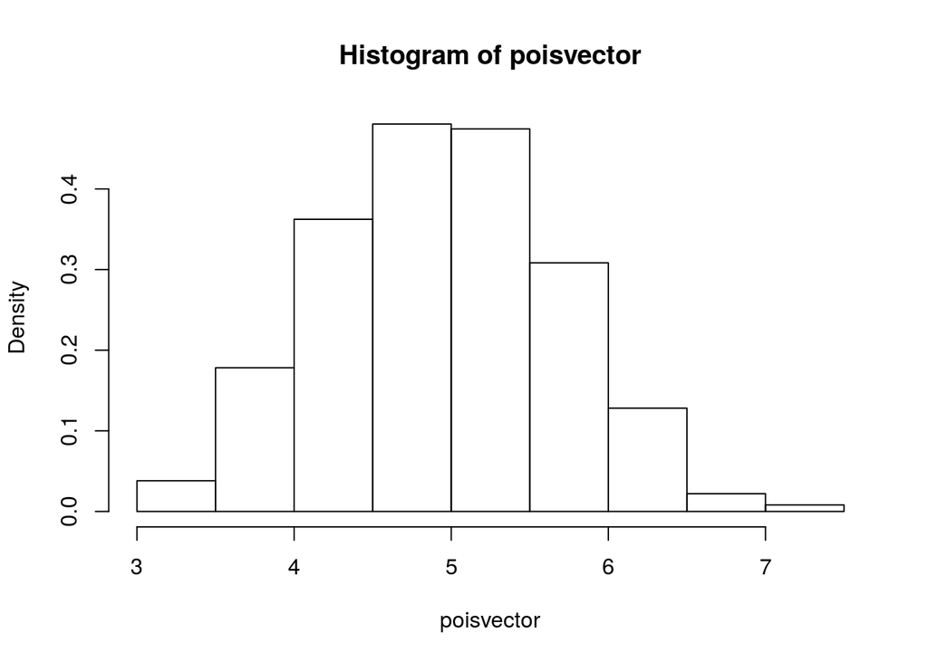

```r
hist(poisvector, probability = TRUE)
```

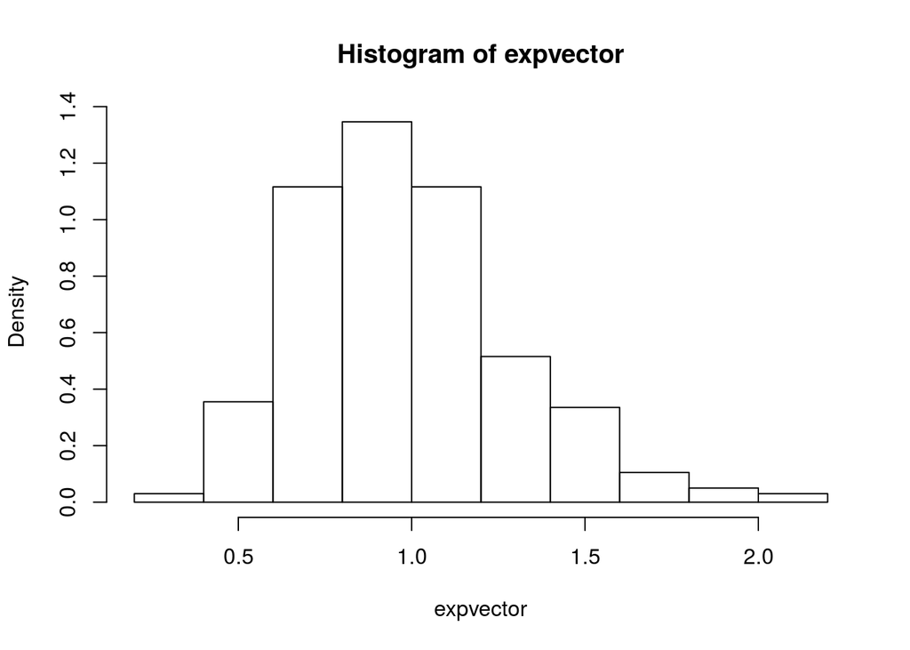

```r
hist(expvector, probability = TRUE)
```